# Airline On-Time Performance Analysis (Part I)

##### Exploratory Visualizations

## Introduction

> **Dataset Description:** This dataset reports flights in the United States, including carriers, arrival and departure delays, and reasons for delays in the year 2006. It also contains data on airports and airplanes. Four (4) tables/.csv files are used in this analysis. They include:
> 1. **2006.csv** - flights report in the year 2006
> 2. **carriers.csv** - airline information
> 3. **airports.csv** - airport information such as city, state, country, latitude and longitude.
> 4. **plane-data.csv** - plane info such as type, manufacturer, model, engine type, etc.

> All files are available for download [here](https://dataverse.harvard.edu/dataset.xhtml?persistentId=doi:10.7910/DVN/HG7NV7)

## Preliminary Wrangling

```python
!pip install geopy
```

```python
# import required libraries

import os
import zipfile
import numpy as np
import pandas as pd
import matplotlib.pyplot as plt
import seaborn as sns
from geopy.geocoders import Nominatim
```

```python
# extract data from zipped folder
if not os.path.exists('flights_data'):
    with zipfile.ZipFile('flights_data.zip', 'r') as zipped_file:
        zipped_file.extractall()
```

```python
# load data dictionary
data_dict = pd.read_csv('flights_data/variable-descriptions.csv', header=2, index_col=0).replace({"12-Jan":"1 (Jan) - 12 (Dec)",
                                                                                                  '31-Jan':'1 - 31'})
data_dict
```

|  | Name | Description |
| --- | --- | --- |
| 1 | Year | 1987-2008 |
| 2 | Month | 1 (Jan) - 12 (Dec) |
| 3 | DayofMonth | 1 - 31 |
| 4 | DayOfWeek | 1 (Monday) - 7 (Sunday) |
| 5 | DepTime | actual departure time (local, hhmm) |
| 6 | CRSDepTime | scheduled departure time (local, hhmm) |
| 7 | ArrTime | actual arrival time (local, hhmm) |
| 8 | CRSArrTime | scheduled arrival time (local, hhmm) |
| 9 | UniqueCarrier | unique carrier code |
| 10 | FlightNum | flight number |
| 11 | TailNum | plane tail number |
| 12 | ActualElapsedTime | in minutes |
| 13 | CRSElapsedTime | in minutes |
| 14 | AirTime | in minutes |
| 15 | ArrDelay | arrival delay, in minutes |
| 16 | DepDelay | departure delay, in minutes |
| 17 | Origin | origin IATA airport code |
| 18 | Dest | destination IATA airport code |
| 19 | Distance | in miles |
| 20 | TaxiIn | taxi in time, in minutes |
| 21 | TaxiOut | taxi out time in minutes |
| 22 | Cancelled | was the flight cancelled? |
| 23 | CancellationCode | reason for cancellation (A = carrier, B = weat... |
| 24 | Diverted | 1 = yes, 0 = no |
| 25 | CarrierDelay | in minutes |
| 26 | WeatherDelay | in minutes |
| 27 | NASDelay | in minutes |
| 28 | SecurityDelay | in minutes |
| 29 | LateAircraftDelay | in minutes |

```python
# extract column names
list(data_dict.Name)
```

```
['Year',
 'Month',
 'DayofMonth',
 'DayOfWeek',
 'DepTime',
 'CRSDepTime',
 'ArrTime',
 'CRSArrTime',
 'UniqueCarrier',
 'FlightNum',
 'TailNum',
 'ActualElapsedTime',
 'CRSElapsedTime',
 'AirTime',
 'ArrDelay',
 'DepDelay',
 'Origin',
 'Dest',
 'Distance',
 'TaxiIn',
 'TaxiOut',
 'Cancelled',
 'CancellationCode',
 'Diverted',
 'CarrierDelay',
 'WeatherDelay',
 'NASDelay',
 'SecurityDelay',
 'LateAircraftDelay']
```

```python
# load datasets - load only columns of interest
flights = pd.read_csv('flights_data/2006.csv',  usecols=['Year', 'Month', 'DayofMonth', 'DayOfWeek', 'DepTime', 'CRSDepTime',
                                                       'ArrTime', 'CRSArrTime', 'UniqueCarrier', 'FlightNum', 'TailNum',
                                                       'ArrDelay', 'DepDelay', 'Origin', 'Dest', 'Distance', 'Cancelled',
                                                       'CancellationCode'])
airlines_df = pd.read_csv('flights_data/carriers.csv')
airports_df = pd.read_csv('flights_data/airports.csv')
airplanes_df = pd.read_csv('flights_data/plane-data.csv')
```

## Assessing Data

In this section, I will be accessing the data in order to familiarize with the structure as well as detect and document all quality and tidiness issues which I will address.

```python
# inspect data
print('flights:', flights.shape, '\n')
print(flights.info(show_counts=True), '\n')
print('airlines_df:', airlines_df.shape, '\n')
print(airlines_df.info(), '\n')
print('airports_df:', airports_df.shape, '\n')
print(airports_df.info(), '\n')
print('airplanes_df:', airplanes_df.shape, '\n')
print(airplanes_df.info(), '\n')
```

```
flights: (7141922, 18)

<class 'pandas.core.frame.DataFrame'>
RangeIndex: 7141922 entries, 0 to 7141921
Data columns (total 18 columns):
 #   Column            Non-Null Count    Dtype
---  ------            --------------    -----
 0   Year              7141922 non-null  int64
 1   Month             7141922 non-null  int64
 2   DayofMonth        7141922 non-null  int64
 3   DayOfWeek         7141922 non-null  int64
 4   DepTime           7019988 non-null  float64
 5   CRSDepTime        7141922 non-null  int64
 6   ArrTime           7003802 non-null  float64
 7   CRSArrTime        7141922 non-null  int64
 8   UniqueCarrier     7141922 non-null  object
 9   FlightNum         7141922 non-null  int64
 10  TailNum           7141922 non-null  object
 11  ArrDelay          7003802 non-null  float64
 12  DepDelay          7019988 non-null  float64
 13  Origin            7141922 non-null  object
 14  Dest              7141922 non-null  object
 15  Distance          7141922 non-null  int64
 16  Cancelled         7141922 non-null  int64
 17  CancellationCode  121934 non-null   object
dtypes: float64(4), int64(9), object(5)
memory usage: 980.8+ MB
None

airlines_df: (1491, 2)

<class 'pandas.core.frame.DataFrame'>
RangeIndex: 1491 entries, 0 to 1490
Data columns (total 2 columns):
 #   Column       Non-Null Count  Dtype
---  ------       --------------  -----
 0   Code         1490 non-null   object
 1   Description  1491 non-null   object
dtypes: object(2)
memory usage: 23.4+ KB
```

[output cut: 24 more lines]

```
Data columns (total 9 columns):
 #   Column         Non-Null Count  Dtype
---  ------         --------------  -----
 0   tailnum        5029 non-null   object
 1   type           4480 non-null   object
 2   manufacturer   4480 non-null   object
 3   issue_date     4480 non-null   object
 4   model          4480 non-null   object
 5   status         4480 non-null   object
 6   aircraft_type  4480 non-null   object
 7   engine_type    4480 non-null   object
 8   year           4480 non-null   object
dtypes: object(9)
memory usage: 353.7+ KB
None
```

```python
# view 2006 flights record
flights.head()
```

|  | Year | Month | DayofMonth | DayOfWeek | DepTime | CRSDepTime | ArrTime | CRSArrTime | UniqueCarrier | FlightNum | TailNum | ArrDelay | DepDelay | Origin | Dest | Distance | Cancelled | CancellationCode |
| --- | --- | --- | --- | --- | --- | --- | --- | --- | --- | --- | --- | --- | --- | --- | --- | --- | --- | --- |
| 0 | 2006 | 1 | 11 | 3 | 743.0 | 745 | 1024.0 | 1018 | US | 343 | N657AW | 6.0 | -2.0 | ATL | PHX | 1587 | 0 | NaN |
| 1 | 2006 | 1 | 11 | 3 | 1053.0 | 1053 | 1313.0 | 1318 | US | 613 | N834AW | -5.0 | 0.0 | ATL | PHX | 1587 | 0 | NaN |
| 2 | 2006 | 1 | 11 | 3 | 1915.0 | 1915 | 2110.0 | 2133 | US | 617 | N605AW | -23.0 | 0.0 | ATL | PHX | 1587 | 0 | NaN |
| 3 | 2006 | 1 | 11 | 3 | 1753.0 | 1755 | 1925.0 | 1933 | US | 300 | N312AW | -8.0 | -2.0 | AUS | PHX | 872 | 0 | NaN |
| 4 | 2006 | 1 | 11 | 3 | 824.0 | 832 | 1015.0 | 1015 | US | 765 | N309AW | 0.0 | -8.0 | AUS | PHX | 872 | 0 | NaN |

```python
# view airlines table
airlines_df.head()
```

|  | Code | Description |
| --- | --- | --- |
| 0 | 02Q | Titan Airways |
| 1 | 04Q | Tradewind Aviation |
| 2 | 05Q | Comlux Aviation, AG |
| 3 | 06Q | Master Top Linhas Aereas Ltd. |
| 4 | 07Q | Flair Airlines Ltd. |

```python
# view airports table
airports_df.head()
```

|  | iata | airport | city | state | country | lat | long |
| --- | --- | --- | --- | --- | --- | --- | --- |
| 0 | 00M | Thigpen | Bay Springs | MS | USA | 31.953765 | -89.234505 |
| 1 | 00R | Livingston Municipal | Livingston | TX | USA | 30.685861 | -95.017928 |
| 2 | 00V | Meadow Lake | Colorado Springs | CO | USA | 38.945749 | -104.569893 |
| 3 | 01G | Perry-Warsaw | Perry | NY | USA | 42.741347 | -78.052081 |
| 4 | 01J | Hilliard Airpark | Hilliard | FL | USA | 30.688012 | -81.905944 |

```python
# view airplanes table
airplanes_df.sample(5)
```

|  | tailnum | type | manufacturer | issue_date | model | status | aircraft_type | engine_type | year |
| --- | --- | --- | --- | --- | --- | --- | --- | --- | --- |
| 2230 | N515AA | NaN | NaN | NaN | NaN | NaN | NaN | NaN | NaN |
| 1696 | N415AA | Corporation | MCDONNELL DOUGLAS | 09/09/1986 | DC-9-82(MD-82) | Valid | Fixed Wing Multi-Engine | Turbo-Fan | 1986 |
| 4439 | N904FR | Corporation | AIRBUS INDUSTRIE | 06/21/2007 | A319-111 | Valid | Fixed Wing Multi-Engine | Turbo-Jet | 2001 |
| 3241 | N677UA | Corporation | BOEING | 12/11/2001 | 767-322 | Valid | Fixed Wing Multi-Engine | Turbo-Fan | 2001 |
| 1086 | N322SW | Corporation | BOEING | 01/30/2008 | 737-3H4 | Valid | Fixed Wing Multi-Engine | Turbo-Fan | 1987 |

### Checking for duplicates and nulls

```python
# check for nulls and duplicates in 2006 record
print('duplicated:', flights.duplicated().sum(), '\n')
flights.isnull().sum()
```

```
duplicated: 7
```

```
Year                      0
Month                     0
DayofMonth                0
DayOfWeek                 0
DepTime              121934
CRSDepTime                0
ArrTime              138120
CRSArrTime                0
UniqueCarrier             0
FlightNum                 0
TailNum                   0
ArrDelay             138120
DepDelay             121934
Origin                    0
Dest                      0
Distance                  0
Cancelled                 0
CancellationCode    7019988
dtype: int64
```

```python
# comparing 0's in Cancelled to nulls in cancellation code - they match
flights.Cancelled.value_counts()
```

```
0    7019988
1     121934
Name: Cancelled, dtype: int64
```

```python
# check for nulls and duplicates in the airlines table
print('duplicated:', airlines_df.duplicated().sum(), '\n')
airlines_df.isnull().sum()
```

```
duplicated: 0
```

```
Code           1
Description    0
dtype: int64
```

```python
# look at airline with null code value
airlines_df[airlines_df['Code'].isnull()]
```

|  | Code | Description |
| --- | --- | --- |
| 873 | NaN | North American Airlines |

```python
# check for nulls and duplicates in the airports table
print('duplicated:', airports_df.duplicated().sum(), '\n')
airports_df.isnull().sum()
```

```
duplicated: 0
```

```
iata        0
airport     0
city       12
state      12
country     0
lat         0
long        0
dtype: int64
```

```python
# look at airports with null city and states value
airports_df[airports_df['city'].isnull() | airports_df['state'].isnull()]
```

|  | iata | airport | city | state | country | lat | long |
| --- | --- | --- | --- | --- | --- | --- | --- |
| 1136 | CLD | MC Clellan-Palomar Airport | NaN | NaN | USA | 33.127231 | -117.278727 |
| 1715 | HHH | Hilton Head | NaN | NaN | USA | 32.224384 | -80.697629 |
| 2251 | MIB | Minot AFB | NaN | NaN | USA | 48.415769 | -101.358039 |
| 2312 | MQT | Marquette County Airport | NaN | NaN | USA | 46.353639 | -87.395361 |
| 2752 | RCA | Ellsworth AFB | NaN | NaN | USA | 44.145094 | -103.103567 |
| 2759 | RDR | Grand Forks AFB | NaN | NaN | USA | 47.961167 | -97.401167 |
| 2794 | ROP | Prachinburi | NaN | NaN | Thailand | 14.078333 | 101.378334 |
| 2795 | ROR | Babelthoup/Koror | NaN | NaN | Palau | 7.367222 | 134.544167 |
| 2900 | SCE | University Park | NaN | NaN | USA | 40.851206 | -77.846302 |
| 2964 | SKA | Fairchild AFB | NaN | NaN | USA | 47.615058 | -117.655803 |
| 3001 | SPN | Tinian International Airport | NaN | NaN | N Mariana Islands | 14.996111 | 145.621384 |
| 3355 | YAP | Yap International | NaN | NaN | Federated States of Micronesia | 9.516700 | 138.100000 |

```python
# check for nulls and duplicates in the airplanes table
print('duplicated:', airplanes_df.duplicated().sum(), '\n')
airplanes_df.isnull().sum()
```

```
duplicated: 0
```

```
tailnum            0
type             549
manufacturer     549
issue_date       549
model            549
status           549
aircraft_type    549
engine_type      549
year             549
dtype: int64
```

```python
# inspect departure and arrival times
flights[['CRSArrTime', 'ArrTime', 'CRSDepTime', 'DepTime']].sample(10)
```

|  | CRSArrTime | ArrTime | CRSDepTime | DepTime |
| --- | --- | --- | --- | --- |
| 4759101 | 2000 | 2039.0 | 1805 | 1846.0 |
| 2118022 | 1232 | 1214.0 | 940 | 934.0 |
| 4413343 | 819 | 857.0 | 610 | 609.0 |
| 6591337 | 1750 | 1802.0 | 1650 | 1659.0 |
| 7106819 | 1325 | 1319.0 | 1100 | 1058.0 |
| 402198 | 1807 | 1757.0 | 1510 | 1508.0 |
| 6777323 | 1206 | 1138.0 | 1037 | 1028.0 |
| 343295 | 1943 | 2005.0 | 1903 | 1919.0 |
| 3932050 | 2012 | 2010.0 | 1234 | 1241.0 |
| 3113771 | 1517 | 1608.0 | 1437 | 1526.0 |

```python
# check if there are cases of incorrect time where minutes exceed '59'
flights[((flights['CRSArrTime'] > 59) & (flights['CRSArrTime'] < 100))|
        ((flights['ArrTime'] > 59) & (flights['ArrTime'] < 100))|
        ((flights['CRSDepTime'] > 59) & (flights['CRSDepTime'] < 100))|
        ((flights['DepTime'] > 59) & (flights['DepTime'] < 100))]
```

|  | Year | Month | DayofMonth | DayOfWeek | DepTime | CRSDepTime | ArrTime | CRSArrTime | UniqueCarrier | FlightNum | TailNum | ArrDelay | DepDelay | Origin | Dest | Distance | Cancelled | CancellationCode |
| --- | --- | --- | --- | --- | --- | --- | --- | --- | --- | --- | --- | --- | --- | --- | --- | --- | --- | --- |

```python
# subset the 2006 flights record table for arrival and departure times with less than 3 digits
flights[(flights['CRSArrTime'] < 100)|(flights['ArrTime'] < 100)|(flights['CRSDepTime'] < 100)|(flights['DepTime'] < 100)]
```

|  | Year | Month | DayofMonth | DayOfWeek | DepTime | CRSDepTime | ArrTime | CRSArrTime | UniqueCarrier | FlightNum | TailNum | ArrDelay | DepDelay | Origin | Dest | Distance | Cancelled | CancellationCode |
| --- | --- | --- | --- | --- | --- | --- | --- | --- | --- | --- | --- | --- | --- | --- | --- | --- | --- | --- |
| 145 | 2006 | 1 | 11 | 3 | 2144.0 | 2135 | 5.0 | 2329 | US | 40 | N174UW | 36.0 | 9.0 | CLT | BOS | 728 | 0 | NaN |
| 195 | 2006 | 1 | 11 | 3 | 2234.0 | 2145 | 19.0 | 2332 | US | 918 | N335US | 47.0 | 49.0 | CLT | EWR | 529 | 0 | NaN |
| 538 | 2006 | 1 | 11 | 3 | 22.0 | 2359 | 914.0 | 851 | US | 925 | N908AW | 23.0 | 23.0 | HNL | PHX | 2917 | 0 | NaN |
| 571 | 2006 | 1 | 11 | 3 | 2148.0 | 1955 | 8.0 | 2158 | US | 984 | N742UW | 130.0 | 113.0 | JAX | PHL | 742 | 0 | NaN |
| 579 | 2006 | 1 | 11 | 3 | 1556.0 | 1600 | 17.0 | 2357 | US | 64 | N656AW | 20.0 | -4.0 | LAS | BOS | 2381 | 0 | NaN |
| ... | ... | ... | ... | ... | ... | ... | ... | ... | ... | ... | ... | ... | ... | ... | ... | ... | ... | ... |
| 7141708 | 2006 | 12 | 29 | 5 | 49.0 | 55 | 609.0 | 531 | DL | 1464 | N3753 | 38.0 | -6.0 | DEN | ATL | 1199 | 0 | NaN |
| 7141800 | 2006 | 12 | 29 | 5 | 2143.0 | 2140 | 11.0 | 2254 | DL | 1555 | N947DL | 77.0 | 3.0 | ATL | IAH | 689 | 0 | NaN |
| 7141824 | 2006 | 12 | 29 | 5 | 2141.0 | 2145 | 6.0 | 14 | DL | 1578 | N3754A | -8.0 | -4.0 | ATL | BOS | 946 | 0 | NaN |
| 7141895 | 2006 | 12 | 29 | 5 | 2243.0 | 2245 | 25.0 | 27 | DL | 1648 | N981DL | -2.0 | -2.0 | ATL | FLL | 581 | 0 | NaN |
| 7141904 | 2006 | 12 | 29 | 5 | 2010.0 | 2010 | 11.0 | 2345 | DL | 1656 | N926DL | 26.0 | 0.0 | JFK | FLL | 1069 | 0 | NaN |

120213 rows × 18 columns

```python
# check for flights with arrival or departure time as 0
flights[(flights['DepTime'] == 0)|(flights['ArrTime'] == 0)]
```

|  | Year | Month | DayofMonth | DayOfWeek | DepTime | CRSDepTime | ArrTime | CRSArrTime | UniqueCarrier | FlightNum | TailNum | ArrDelay | DepDelay | Origin | Dest | Distance | Cancelled | CancellationCode |
| --- | --- | --- | --- | --- | --- | --- | --- | --- | --- | --- | --- | --- | --- | --- | --- | --- | --- | --- |

```python
# look at the description for cancellation code column
data_dict.iloc[22,1]
```

```
'reason for cancellation (A = carrier, B = weather, C = NAS, D = security)'
```

## Quality Issues

- capitalized letters in column names in the flights table **(for uniformity, all column names should be lowercase and words should be sepearated using underscores)**
- some arrival and departure times have only 1 or 2 digits that seem not to correspond to a valid time. This is probably because excel removes leading 0s and we can have up to about 3 leading 0s **(add the missing leading 0s)**.
- incorrect time representation - **(change the arrival and departure times to hh:mm format by inserting ":" at appropriate points)**
- Year, Month, DayofMonth and DayofWeek columns **(use the year, month and day of month to form a date column), (change month from numbers 1-12 to Jan-Dec), (change day of week from 1-7 to Mon-Sun and make them categorical types), (year should also be changed to str dtype), (day of month should be string)**
- the cancellation code in the flights table should be transformed as follows: **(reason for cancellation (A = carrier, B = weather, C = NAS, D = security)**
- the cancelled column should be transformed as follows: **(0 = NO, 1 = YES)**
- the missing values in the CancellationCode column - **(if flight was not cancelled, let reason be 'not cancelled')**
- missing arrival and departure times in flights table, missing departure times corresponds to cancelled flight - **(but some records have departure times but missing arrival times and these flights were not cancelled, these rows should be dropped)**
- duplicates in flights table - **(drop duplicates)**
- one missing airline code in the airlines table - **(drop this)**
- rename **year** column in airplanes table to **manufacturing_year**
- rename **Description** column in airplanes table to **airline**
- incorrect datatype **(the issue_date in the airplanes table should be datetime)**, **(latitude and longitude in the airports table should be str datatypes)**
- extract **year** from **issue_date** to replace the year column as it has some incorrect entries
- 12 records missing city and state values in the airports table - **(these can be found using the geopy module and by an online search using the airport name, find and input these values)**
- 549 records only have 'tailnum' recorded in the airplanes table - **(these will not be relevant to the analysis, they should be dropped)**

> **After these cleaning operations, I will recompute the ArrDelay and DepDelay columns.**

## Tidiness Issues

- drop columns that are not needed
- merge the resulting flights table with the airports, airplanes and airlines table to form one master dataset which will be explored further using exploratory visualizations.

Finally, the last step will be to engineer a flight status column that identifies a flight as "on-time" or "delayed".

- A flight is considered on-time when it arrives less than 15 minutes after its published arrival time. A flight arriving or departing 15 minutes or more after the scheduled time is considered a late flight.

# Cleaning Data

```python
# Make copies of original pieces of data - cleaning operations will be performed on these

flights_clean = flights.copy()
airlines_clean = airlines_df.copy()
airports_clean = airports_df.copy()

airplanes_clean = airplanes_df.copy()
```

```python
column_names = ['year', 'month', 'day', 'day_of_week', 'dep_time', 'sched_dep_time', 'arr_time', 'sched_arr_time',
                'carrier_code', 'flight_num', 'tailnum', 'arr_delay', 'dep_delay', 'iata_origin', 'iata_dest', 'distance',
                'cancelled', 'reason_for_cancel']

months_dict = {1:'Jan', 2:'Feb', 3:'Mar', 4:'Apr', 5:'May', 6:'Jun', 7:'Jul', 8:'Aug', 9:'Sept', 10:'Oct', 11:'Nov', 12:'Dec'}

day_of_week_dict = {1:'Mon', 2:'Tues', 3:'Wed', 4:'Thurs', 5:'Fri', 6:'Sat', 7:'Sun'}

cancel_reason_dict = {'A':'carrier', 'B':'weather', 'C':'NAS', 'D':'security', np.nan:'not cancelled'}

cancelled = {0:'NO', 1:'YES'}
```

```python
def clean_flight_record(df):
    """
        Function to perform cleaning operations on flight record tables. This cleaning operations address the
        quality issues detected and documented above.

        Input: flight record dataframe to be cleaned (clean_05 or clean_06).

        Returns: a cleaned dataframe
    """
    # subset table to drop records with departure time but no arrival time
    df = df[~(df['DepTime'].notnull() & df['ArrTime'].isnull())]

    # fill missing departure and arrival times with 0s
    df['DepTime'].fillna(0, inplace=True)
    df['ArrTime'].fillna(0, inplace=True)

    # change column names
    df.columns = column_names

    # change encoding for month and day_of_week, cancel and cancel code
    df['month'].replace(months_dict, inplace=True)
    df['day_of_week'].replace(day_of_week_dict, inplace=True)
    df['cancelled'].replace(cancelled, inplace=True)
    df['reason_for_cancel'].replace(cancel_reason_dict, inplace=True)

    # drop duplicate records
    df.drop_duplicates(inplace=True, ignore_index=True)

    # setting appropriate datatypes
    df['year'] = df['year'].astype(str)
    df['day'] = df['day'].astype(str)
    months = pd.api.types.CategoricalDtype(ordered = True, categories = ['Jan', 'Feb', 'Mar', 'Apr', 'May', 'Jun', 'Jul',
                                                                         'Aug', 'Sept', 'Oct', 'Nov', 'Dec'])
    weekday = pd.api.types.CategoricalDtype(ordered = True, categories = ['Mon', 'Tues', 'Wed', 'Thurs', 'Fri', 'Sat', 'Sun'])
    df['month'] = df['month'].astype(months)
    df['day_of_week'] = df['day_of_week'].astype(weekday)
    df['dep_time'] = df['dep_time'].astype(int) # change from float to int first to remove the floating point
    df['dep_time'] = df['dep_time'].astype(str)
    df['sched_dep_time'] = df['sched_dep_time'].astype(str)
    df['arr_time'] = df['arr_time'].astype(int) # change from float to int first to remove the floating point
    df['arr_time'] = df['arr_time'].astype(str)
    df['sched_arr_time'] = df['sched_arr_time'].astype(str)


    # format time to 4-digit strings
    df['dep_time'] = df.apply(lambda x: '000'+x['dep_time'] if len(x['dep_time']) == 1
                                                            else ('00'+x['dep_time'] if len(x['dep_time']) == 2
                                                            else x['dep_time']), axis=1)
    df['arr_time'] = df.apply(lambda x: '000'+x['arr_time'] if len(x['arr_time']) == 1
                                                            else ('00'+x['arr_time'] if len(x['arr_time']) == 2
                                                            else x['arr_time']), axis=1)
    df['sched_dep_time'] = df.apply(lambda x: '000'+x['sched_dep_time'] if len(x['sched_dep_time']) == 1
                                                            else ('00'+x['sched_dep_time'] if len(x['sched_dep_time']) == 2
                                                            else x['sched_dep_time']), axis=1)
    df['sched_arr_time'] = df.apply(lambda x: '000'+x['sched_arr_time'] if len(x['sched_arr_time']) == 1
                                                            else ('00'+x['sched_arr_time'] if len(x['sched_arr_time']) == 2
                                                            else x['sched_arr_time']), axis=1)


    # format time colums to hh:mm:ss
    df['dep_time'] = df.apply(lambda x: x['dep_time'][:-2] + ":" + x['dep_time'][-2:] + ":00", axis=1)
    df['arr_time'] = df.apply(lambda x: x['arr_time'][:-2] + ":" + x['arr_time'][-2:] + ":00", axis=1)
    df['sched_dep_time'] = df.apply(lambda x: x['sched_dep_time'][:-2] + ":" + x['sched_dep_time'][-2:] + ":00", axis=1)
    df['sched_arr_time'] = df.apply(lambda x: x['sched_arr_time'][:-2] + ":" + x['sched_arr_time'][-2:] + ":00", axis=1)

    # return 00:00:00 arrival and departure time values to NaN
    df['dep_time'].replace('00:00:00', np.NaN, inplace=True)
    df['arr_time'].replace('00:00:00', np.NaN, inplace=True)

    # display dataframe
    return df
```

```python
# to turn off warning
pd.options.mode.chained_assignment = None
```

```python
# clean 2006 record
flights_clean = clean_flight_record(flights_clean)
```

```python
# inspect cleaned 2006 data
print(flights_clean.shape)
print(flights_clean.info(show_counts=True))
flights_clean.head()
```

```
(7125730, 18)
<class 'pandas.core.frame.DataFrame'>
RangeIndex: 7125730 entries, 0 to 7125729
Data columns (total 18 columns):
 #   Column             Non-Null Count    Dtype
---  ------             --------------    -----
 0   year               7125730 non-null  object
 1   month              7125730 non-null  category
 2   day                7125730 non-null  object
 3   day_of_week        7125730 non-null  category
 4   dep_time           7003796 non-null  object
 5   sched_dep_time     7125730 non-null  object
 6   arr_time           7003796 non-null  object
 7   sched_arr_time     7125730 non-null  object
 8   carrier_code       7125730 non-null  object
 9   flight_num         7125730 non-null  int64
 10  tailnum            7125730 non-null  object
 11  arr_delay          7003796 non-null  float64
 12  dep_delay          7003796 non-null  float64
 13  iata_origin        7125730 non-null  object
 14  iata_dest          7125730 non-null  object
 15  distance           7125730 non-null  int64
 16  cancelled          7125730 non-null  object
 17  reason_for_cancel  7125730 non-null  object
dtypes: category(2), float64(2), int64(2), object(12)
memory usage: 883.4+ MB
None
```

|  | year | month | day | day_of_week | dep_time | sched_dep_time | arr_time | sched_arr_time | carrier_code | flight_num | tailnum | arr_delay | dep_delay | iata_origin | iata_dest | distance | cancelled | reason_for_cancel |
| --- | --- | --- | --- | --- | --- | --- | --- | --- | --- | --- | --- | --- | --- | --- | --- | --- | --- | --- |
| 0 | 2006 | Jan | 11 | Wed | 7:43:00 | 7:45:00 | 10:24:00 | 10:18:00 | US | 343 | N657AW | 6.0 | -2.0 | ATL | PHX | 1587 | NO | not cancelled |
| 1 | 2006 | Jan | 11 | Wed | 10:53:00 | 10:53:00 | 13:13:00 | 13:18:00 | US | 613 | N834AW | -5.0 | 0.0 | ATL | PHX | 1587 | NO | not cancelled |
| 2 | 2006 | Jan | 11 | Wed | 19:15:00 | 19:15:00 | 21:10:00 | 21:33:00 | US | 617 | N605AW | -23.0 | 0.0 | ATL | PHX | 1587 | NO | not cancelled |
| 3 | 2006 | Jan | 11 | Wed | 17:53:00 | 17:55:00 | 19:25:00 | 19:33:00 | US | 300 | N312AW | -8.0 | -2.0 | AUS | PHX | 872 | NO | not cancelled |
| 4 | 2006 | Jan | 11 | Wed | 8:24:00 | 8:32:00 | 10:15:00 | 10:15:00 | US | 765 | N309AW | 0.0 | -8.0 | AUS | PHX | 872 | NO | not cancelled |

```python
# drop null value in airlines table
airlines_clean.dropna(inplace=True)
```

```python
# modify column names in airlines table
airlines_clean.columns = ["carrier_code", "carrier"]
```

```python
# confirm that there are no more null values and that column names have changed
print(airlines_clean.shape)
airlines_clean.isnull().sum()
```

```
(1490, 2)
```

```
carrier_code    0
carrier         0
dtype: int64
```

```python
# change data type of longitude and latitude in airports table
airports_clean['lat'] = airports_clean['lat'].astype(str)
airports_clean['long'] = airports_clean['long'].astype(str)
```

```python
# confirm changes
airports_clean.info()
```

```
<class 'pandas.core.frame.DataFrame'>
RangeIndex: 3376 entries, 0 to 3375
Data columns (total 7 columns):
 #   Column   Non-Null Count  Dtype
---  ------   --------------  -----
 0   iata     3376 non-null   object
 1   airport  3376 non-null   object
 2   city     3364 non-null   object
 3   state    3364 non-null   object
 4   country  3376 non-null   object
 5   lat      3376 non-null   object
 6   long     3376 non-null   object
dtypes: object(7)
memory usage: 184.8+ KB
```

```python
# subset for records with missing state and cities
missing_locations = airports_clean.loc[airports_clean.city.isnull()]
missing_locations
```

|  | iata | airport | city | state | country | lat | long |
| --- | --- | --- | --- | --- | --- | --- | --- |
| 1136 | CLD | MC Clellan-Palomar Airport | NaN | NaN | USA | 33.127231 | -117.278727 |
| 1715 | HHH | Hilton Head | NaN | NaN | USA | 32.224384 | -80.697629 |
| 2251 | MIB | Minot AFB | NaN | NaN | USA | 48.415769 | -101.358039 |
| 2312 | MQT | Marquette County Airport | NaN | NaN | USA | 46.353639 | -87.395361 |
| 2752 | RCA | Ellsworth AFB | NaN | NaN | USA | 44.145094 | -103.103567 |
| 2759 | RDR | Grand Forks AFB | NaN | NaN | USA | 47.961167 | -97.401167 |
| 2794 | ROP | Prachinburi | NaN | NaN | Thailand | 14.078333 | 101.378334 |
| 2795 | ROR | Babelthoup/Koror | NaN | NaN | Palau | 7.367222 | 134.544167 |
| 2900 | SCE | University Park | NaN | NaN | USA | 40.851206 | -77.846302 |
| 2964 | SKA | Fairchild AFB | NaN | NaN | USA | 47.615058 | -117.655803 |
| 3001 | SPN | Tinian International Airport | NaN | NaN | N Mariana Islands | 14.996111 | 145.621384 |
| 3355 | YAP | Yap International | NaN | NaN | Federated States of Micronesia | 9.5167 | 138.1 |

```python
# Initialize Nominatim API
geolocator = Nominatim(user_agent="geoapiExercises")

# Get locations with geocode
missing_locations['location'] = missing_locations.apply(lambda x: geolocator.geocode(x['lat'] + "," + x['long']), axis=1)
```

```python
# view locations
for i, location in enumerate(missing_locations['location']):
    index = [1, 2, 3, 4, 5, 6, 7, 8, 9, 10, 11, 12]
    print(str(index[i])+'.', location)
```

```
1. McClellan-Palomar Airport, Geiger Court, Carlsbad Research Center, Carlsbad, San Diego County, California, 92011, United States
2. Hilton Head Airport, Hiltech Lane, Hilton Head Island, Beaufort County, South Carolina, 29926, United States
3. Alert Avenue, Ward County, North Dakota, 58705, United States
4. Sawyer International Airport, Sawyer Avenue, Plains, Forsyth Township, Marquette County, Michigan, 49841, United States
5. Meade County, South Dakota, United States
6. Grand Forks AFB, 22nd Avenue Northeast, Grand Forks County, North Dakota, 58204, United States
7. สนามบินเขาอีโต้, ปจ.2001, ปราจีนบุรี, โคกมะกอก, จังหวัดปราจีนบุรี, 25000, ประเทศไทย
8. Roman Tmetuchl International Airport, Koror-Babeldaob Bridge, Ngetkib, Airai, Belau
9. University Park Airport, Minute Man Road, Patton Township, Centre County, Pennsylvania, 16802, United States
10. Control Tower, Survival Loop, Spokane County, Washington, 99011, United States
11. Tinian International Airport, Airport Road, Tinian Municipality, Northern Mariana Islands, 96952, United States
12. Kanif, Dalipeebinaew, Yap, 96943, Micronesia
```

```python
# dictionary to store cities and states
missing_dict = {'Carlsbad':'CA', 'Hilton Head Island':'SC', 'Minot':'ND', 'Gwinn':'MI', 'Ellsworth':'SD', 'Grand Forks':'ND',
                'Dong Phra Ram':'Prachin Buri', 'Ngetkib':'Airai', 'State College':'PA', 'Fairchild AFB':'WA',
                'San Jose, Tinian':'CNMI', 'Kanif':'Yap'}
```

```python
# input cities and states into table
index = missing_locations.index

for i, key in enumerate(missing_dict):
    airports_clean.loc[index[i], 'city'] = key
    airports_clean.loc[index[i], 'state'] = missing_dict[key]
```

```python
# confirm changes
airports_clean.loc[missing_locations.index]
```

|  | iata | airport | city | state | country | lat | long |
| --- | --- | --- | --- | --- | --- | --- | --- |
| 1136 | CLD | MC Clellan-Palomar Airport | Carlsbad | CA | USA | 33.127231 | -117.278727 |
| 1715 | HHH | Hilton Head | Hilton Head Island | SC | USA | 32.224384 | -80.697629 |
| 2251 | MIB | Minot AFB | Minot | ND | USA | 48.415769 | -101.358039 |
| 2312 | MQT | Marquette County Airport | Gwinn | MI | USA | 46.353639 | -87.395361 |
| 2752 | RCA | Ellsworth AFB | Ellsworth | SD | USA | 44.145094 | -103.103567 |
| 2759 | RDR | Grand Forks AFB | Grand Forks | ND | USA | 47.961167 | -97.401167 |
| 2794 | ROP | Prachinburi | Dong Phra Ram | Prachin Buri | Thailand | 14.078333 | 101.378334 |
| 2795 | ROR | Babelthoup/Koror | Ngetkib | Airai | Palau | 7.367222 | 134.544167 |
| 2900 | SCE | University Park | State College | PA | USA | 40.851206 | -77.846302 |
| 2964 | SKA | Fairchild AFB | Fairchild AFB | WA | USA | 47.615058 | -117.655803 |
| 3001 | SPN | Tinian International Airport | San Jose, Tinian | CNMI | N Mariana Islands | 14.996111 | 145.621384 |
| 3355 | YAP | Yap International | Kanif | Yap | Federated States of Micronesia | 9.5167 | 138.1 |

```python
# drop null value in airplanes table
airplanes_clean.dropna(inplace=True)
```

```python
# confirm that there are no more null values
print(airplanes_clean.shape)
airplanes_clean.isnull().sum()
```

```
(4480, 9)
```

```
tailnum          0
type             0
manufacturer     0
issue_date       0
model            0
status           0
aircraft_type    0
engine_type      0
year             0
dtype: int64
```

```python
airplanes_clean['issue_date']
```

```
34      02/13/2004
35      05/26/1999
36      07/01/1997
37      06/18/1999
38      01/26/1998
           ...
5024    03/11/1992
5025    01/23/2003
5026    04/02/1992
5027    07/09/2008
5028    04/02/1992
Name: issue_date, Length: 4480, dtype: object
```

```python
# view airplanes table where issue date is None
airplanes_clean[airplanes_clean['issue_date'] == "None"]
```

|  | tailnum | type | manufacturer | issue_date | model | status | aircraft_type | engine_type | year |
| --- | --- | --- | --- | --- | --- | --- | --- | --- | --- |
| 1529 | N394AA | Corporation | AVIAT AIRCRAFT INC | None | A-1B | Registered to Mfr | Fixed Wing Single-Engine | Reciprocating | 2007 |

```python
# remove row where issue date is None
airplanes_clean = airplanes_clean[airplanes_clean['issue_date'] != "None"]
```

```python
# confirm changes
airplanes_clean[airplanes_clean['issue_date'] == "None"]
```

|  | tailnum | type | manufacturer | issue_date | model | status | aircraft_type | engine_type | year |
| --- | --- | --- | --- | --- | --- | --- | --- | --- | --- |

```python
# change issue date to datetime
airplanes_clean['issue_date'] = pd.to_datetime(airplanes_clean['issue_date'])
```

```python
airplanes_clean[['issue_date', 'year']].sample(10)
```

|  | issue_date | year |
| --- | --- | --- |
| 3062 | 1997-10-10 | 1997 |
| 4081 | 2000-12-15 | 2000 |
| 4541 | 2002-11-13 | 2002 |
| 2841 | 2000-07-17 | 2000 |
| 1184 | 2002-02-25 | 2002 |
| 409 | 1995-07-12 | 1995 |
| 4441 | 2008-01-30 | None |
| 4908 | 2003-11-14 | 2003 |
| 1636 | 2001-05-02 | 2001 |
| 2059 | 2007-06-04 | 2003 |

```python
# extract year from issue_date to take care of mismatched values
airplanes_clean['issue_year'] = airplanes_clean['issue_date'].dt.year
```

```python
# drop unwanted columns
airplanes_clean.drop(columns=['type', 'issue_date', 'status', 'aircraft_type', 'engine_type', 'year'], inplace=True)
```

```python
# confirm changes
airplanes_clean.info()
```

```
<class 'pandas.core.frame.DataFrame'>
Int64Index: 4479 entries, 34 to 5028
Data columns (total 4 columns):
 #   Column        Non-Null Count  Dtype
---  ------        --------------  -----
 0   tailnum       4479 non-null   object
 1   manufacturer  4479 non-null   object
 2   model         4479 non-null   object
 3   issue_year    4479 non-null   int64
dtypes: int64(1), object(3)
memory usage: 175.0+ KB
```

```python
# recompute arrival delay and departure delay in the flights table to take care of errors
flights_clean['dep_delay'] = (pd.to_timedelta(flights_clean['dep_time']).astype('timedelta64[m]')
                              - pd.to_timedelta(flights_clean['sched_dep_time']).astype('timedelta64[m]'))

flights_clean['arr_delay'] = (pd.to_timedelta(flights_clean['arr_time']).astype('timedelta64[m]')
                              - pd.to_timedelta(flights_clean['sched_arr_time']).astype('timedelta64[m]'))
```

```python
# merge flights and airplanes and airlines tables
flights_planes_carriers = flights_clean.merge(airplanes_clean, on='tailnum').merge(airlines_clean,  on='carrier_code')
flights_planes_carriers.head()
```

|  | year | month | day | day_of_week | dep_time | sched_dep_time | arr_time | sched_arr_time | carrier_code | flight_num | ... | dep_delay | iata_origin | iata_dest | distance | cancelled | reason_for_cancel | manufacturer | model | issue_year | carrier |
| --- | --- | --- | --- | --- | --- | --- | --- | --- | --- | --- | --- | --- | --- | --- | --- | --- | --- | --- | --- | --- | --- |
| 0 | 2006 | Jan | 11 | Wed | 7:43:00 | 7:45:00 | 10:24:00 | 10:18:00 | US | 343 | ... | -2.0 | ATL | PHX | 1587 | NO | not cancelled | AIRBUS INDUSTRIE | A320-232 | 2004 | US Airways Inc. (Merged with America West 9/05... |
| 1 | 2006 | Jan | 11 | Wed | 19:13:00 | 19:12:00 | 23:26:00 | 23:31:00 | US | 9 | ... | 1.0 | PHX | ORD | 1440 | NO | not cancelled | AIRBUS INDUSTRIE | A320-232 | 2004 | US Airways Inc. (Merged with America West 9/05... |
| 2 | 2006 | Jan | 12 | Thurs | 23:55:00 | 23:59:00 | 1:21:00 | 1:31:00 | US | 374 | ... | -4.0 | LAS | OAK | 407 | NO | not cancelled | AIRBUS INDUSTRIE | A320-232 | 2004 | US Airways Inc. (Merged with America West 9/05... |
| 3 | 2006 | Jan | 12 | Thurs | 7:24:00 | 7:29:00 | 10:17:00 | 10:19:00 | US | 182 | ... | -5.0 | ORD | PHX | 1440 | NO | not cancelled | AIRBUS INDUSTRIE | A320-232 | 2004 | US Airways Inc. (Merged with America West 9/05... |
| 4 | 2006 | Jan | 12 | Thurs | 13:05:00 | 13:00:00 | 18:48:00 | 18:50:00 | US | 570 | ... | 5.0 | PHX | TPA | 1788 | NO | not cancelled | AIRBUS INDUSTRIE | A320-232 | 2004 | US Airways Inc. (Merged with America West 9/05... |

5 rows × 22 columns

```python
# subset airports tables to merge __ generate 2 tables for origin and destination
airports_origin = airports_clean[['iata', 'airport', 'city', 'state']].rename(columns={'iata':'iata_origin',
                                                                                       'airport':'airport_origin',
                                                                                       'city':'city_origin',
                                                                                       'state':'state_origin'})
airports_dest = airports_clean[['iata', 'airport', 'city', 'state']].rename(columns={'iata':'iata_dest',
                                                                                     'airport':'airport_dest',
                                                                                     'city':'city_dest',
                                                                                     'state':'state_dest'})
airports_origin.head()
```

|  | iata_origin | airport_origin | city_origin | state_origin |
| --- | --- | --- | --- | --- |
| 0 | 00M | Thigpen | Bay Springs | MS |
| 1 | 00R | Livingston Municipal | Livingston | TX |
| 2 | 00V | Meadow Lake | Colorado Springs | CO |
| 3 | 01G | Perry-Warsaw | Perry | NY |
| 4 | 01J | Hilliard Airpark | Hilliard | FL |

```python
# view destination airports table
airports_dest.head()
```

|  | iata_dest | airport_dest | city_dest | state_dest |
| --- | --- | --- | --- | --- |
| 0 | 00M | Thigpen | Bay Springs | MS |
| 1 | 00R | Livingston Municipal | Livingston | TX |
| 2 | 00V | Meadow Lake | Colorado Springs | CO |
| 3 | 01G | Perry-Warsaw | Perry | NY |
| 4 | 01J | Hilliard Airpark | Hilliard | FL |

```python
# merge all tables
master_flights = flights_planes_carriers.merge(airports_origin, on='iata_origin').merge(airports_dest, on='iata_dest')
```

```python
# inspect master table
print(master_flights.shape)
master_flights.head()
```

```
(5503507, 28)
```

|  | year | month | day | day_of_week | dep_time | sched_dep_time | arr_time | sched_arr_time | carrier_code | flight_num | ... | manufacturer | model | issue_year | carrier | airport_origin | city_origin | state_origin | airport_dest | city_dest | state_dest |
| --- | --- | --- | --- | --- | --- | --- | --- | --- | --- | --- | --- | --- | --- | --- | --- | --- | --- | --- | --- | --- | --- |
| 0 | 2006 | Jan | 11 | Wed | 7:43:00 | 7:45:00 | 10:24:00 | 10:18:00 | US | 343 | ... | AIRBUS INDUSTRIE | A320-232 | 2004 | US Airways Inc. (Merged with America West 9/05... | William B Hartsfield-Atlanta Intl | Atlanta | GA | Phoenix Sky Harbor International | Phoenix | AZ |
| 1 | 2006 | Jan | 18 | Wed | 17:13:00 | 17:05:00 | 19:49:00 | 19:31:00 | US | 285 | ... | AIRBUS INDUSTRIE | A320-232 | 2004 | US Airways Inc. (Merged with America West 9/05... | William B Hartsfield-Atlanta Intl | Atlanta | GA | Phoenix Sky Harbor International | Phoenix | AZ |
| 2 | 2006 | Jan | 25 | Wed | 7:44:00 | 7:45:00 | 10:05:00 | 10:18:00 | US | 343 | ... | AIRBUS INDUSTRIE | A320-232 | 2004 | US Airways Inc. (Merged with America West 9/05... | William B Hartsfield-Atlanta Intl | Atlanta | GA | Phoenix Sky Harbor International | Phoenix | AZ |
| 3 | 2006 | Jan | 27 | Fri | 17:16:00 | 17:05:00 | 19:32:00 | 19:31:00 | US | 285 | ... | AIRBUS INDUSTRIE | A320-232 | 2004 | US Airways Inc. (Merged with America West 9/05... | William B Hartsfield-Atlanta Intl | Atlanta | GA | Phoenix Sky Harbor International | Phoenix | AZ |
| 4 | 2006 | Jan | 4 | Wed | 7:55:00 | 7:55:00 | 10:22:00 | 10:27:00 | US | 343 | ... | AIRBUS INDUSTRIE | A320-232 | 2004 | US Airways Inc. (Merged with America West 9/05... | William B Hartsfield-Atlanta Intl | Atlanta | GA | Phoenix Sky Harbor International | Phoenix | AZ |

5 rows × 28 columns

```python
# generate flight status column
master_flights['flight_status'] = master_flights.apply(lambda x: 'cancelled' if x['cancelled']=='YES'
                                                           else ('on time' if (x['arr_delay'] < 15 and x['dep_delay'] < 15)
                                                           else 'delayed'), axis=1)
```

```python
# feature engineering - time of day
master_flights['sched_dep_hour'] = master_flights.apply(lambda x: int(x['sched_dep_time'][:-6]), axis=1)

d_bins = [0,4,8,12,16,20,24]
d_labels = ['Late Night', 'Early Morning','Morning','Noon','Evening','Night']
master_flights['time_of_day'] = pd.cut(master_flights['sched_dep_hour'], bins=d_bins, labels=d_labels, include_lowest=True)
```

```python
# look at final result
master_flights.sample(5)
```

|  | year | month | day | day_of_week | dep_time | sched_dep_time | arr_time | sched_arr_time | carrier_code | flight_num | ... | carrier | airport_origin | city_origin | state_origin | airport_dest | city_dest | state_dest | flight_status | sched_dep_hour | time_of_day |
| --- | --- | --- | --- | --- | --- | --- | --- | --- | --- | --- | --- | --- | --- | --- | --- | --- | --- | --- | --- | --- | --- |
| 1617296 | 2006 | Oct | 3 | Tues | 8:37:00 | 8:40:00 | 9:59:00 | 10:05:00 | XE | 3207 | ... | Expressjet Airlines Inc. | Newark Intl | Newark | NJ | Norfolk International | Norfolk | VA | on time | 8 | Early Morning |
| 5454283 | 2006 | May | 10 | Wed | 19:30:00 | 19:30:00 | 21:27:00 | 20:50:00 | XE | 2919 | ... | Expressjet Airlines Inc. | George Bush Intercontinental | Houston | TX | Brownsville/S.Padre Island International | Brownsville | TX | delayed | 19 | Evening |
| 5392829 | 2006 | Sept | 30 | Sat | 18:28:00 | 18:30:00 | 20:58:00 | 20:58:00 | OO | 6636 | ... | Skywest Airlines Inc. | Denver Intl | Denver | CO | Bismarck Municipal | Bismarck | ND | on time | 18 | Evening |
| 1231757 | 2006 | May | 1 | Mon | 22:51:00 | 22:55:00 | 00:14:00 | 00:33:00 | FL | 218 | ... | AirTran Airways Corporation | William B Hartsfield-Atlanta Intl | Atlanta | GA | Akron-Canton Regional | Akron | OH | on time | 22 | Night |
| 518578 | 2006 | Feb | 24 | Fri | 5:29:00 | 5:20:00 | 6:41:00 | 6:43:00 | US | 1219 | ... | US Airways Inc. (Merged with America West 9/05... | Baltimore-Washington International | Baltimore | MD | Charlotte/Douglas International | Charlotte | NC | on time | 5 | Early Morning |

5 rows × 31 columns

```python
master_flights.shape
```

```
(5503507, 31)
```

```python
master_flights.columns
```

```
Index(['year', 'month', 'day', 'day_of_week', 'dep_time', 'sched_dep_time',
       'arr_time', 'sched_arr_time', 'carrier_code', 'flight_num', 'tailnum',
       'arr_delay', 'dep_delay', 'iata_origin', 'iata_dest', 'distance',
       'cancelled', 'reason_for_cancel', 'manufacturer', 'model', 'issue_year',
       'carrier', 'airport_origin', 'city_origin', 'state_origin',
       'airport_dest', 'city_dest', 'state_dest', 'flight_status',
       'sched_dep_hour', 'time_of_day'],
      dtype='object')
```

```python
flights_plot = master_flights.drop(columns=['day', 'dep_time', 'sched_dep_time',  'arr_time', 'sched_arr_time',
                                            'iata_origin', 'iata_dest', 'sched_dep_hour', 'flight_num', 'tailnum',
                                            'manufacturer', 'model', 'issue_year'])
```

```python
# null values in arrival and departure delays represent cancelled flights
flights_plot.info(show_counts=True)
```

```
<class 'pandas.core.frame.DataFrame'>
Int64Index: 5503507 entries, 0 to 5503506
Data columns (total 18 columns):
 #   Column             Non-Null Count    Dtype
---  ------             --------------    -----
 0   year               5503507 non-null  object
 1   month              5503507 non-null  category
 2   day_of_week        5503507 non-null  category
 3   carrier_code       5503507 non-null  object
 4   arr_delay          5470030 non-null  float64
 5   dep_delay          5470030 non-null  float64
 6   distance           5503507 non-null  int64
 7   cancelled          5503507 non-null  object
 8   reason_for_cancel  5503507 non-null  object
 9   carrier            5503507 non-null  object
 10  airport_origin     5503507 non-null  object
 11  city_origin        5503507 non-null  object
 12  state_origin       5503507 non-null  object
 13  airport_dest       5503507 non-null  object
 14  city_dest          5503507 non-null  object
 15  state_dest         5503507 non-null  object
 16  flight_status      5503507 non-null  object
 17  time_of_day        5503507 non-null  category
dtypes: category(3), float64(2), int64(1), object(12)
memory usage: 687.6+ MB
```

### Structure of the data:

There are 5,503,507 flight records in the flights_plot dataset with 18 features: **('year', 'month', 'day_of_week', 'carrier_code', 'arr_delay', 'dep_delay', 'distance', 'cancelled', 'reason_for_cancel', 'carrier', 'airport_origin', 'city_origin', 'state_origin', 'airport_dest', 'city_dest', 'state_dest', 'flight_status', 'time_of_day')** distributed across quantitative and qualitative datatypes.

### Main features of interest:

> I'm most interested in figuring out what features are responsible for **flight delays** and **flight cancellations**. I am looking to answer the following questions:
> - When is the best time of day/day/week/time of year to fly to minimise delays?
> - What is the top reason for flight cancellations?
> - Are there certain airlines that are home to more delays or cancellations?

### What features in the dataset do you think will help support your investigation into your feature(s) of interest?

> I expect that factors such as **time of the year**, **day of the week**, **time of day**, **location**, **carrier**(or airline) as well as **weather** affect the status of a flight (whether it is on time, is delayed or cancelled).

## Univariate Exploration

> In this section, I will investigate distributions of individual variables. These will help me to take a deeper look at the dataset, clean things up in case of any unusual points or outliers, and prepare to look at relationships between variables.

I'll start by looking at the distribution of the main variables of interest: **flight_status** and **reason_for_cancel**:

```python
flights_plot.flight_status.value_counts()
```

```
on time      4002434
delayed      1467596
cancelled      33477
Name: flight_status, dtype: int64
```

```python
def insert_pct(df, column, y_plus):
    for i in range(df[column].nunique()):
        count = df[column].value_counts()[i]
        total = df[column].count()
        pct_string = f"{100*count/total:0.2f}%"
        plt.text(i, count+y_plus, pct_string, ha='center', va='center');
```

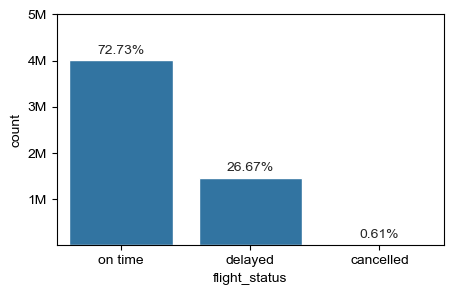

```python
# countplot of flight status
plt.subplots(figsize=(5, 3))
sns.set_style('whitegrid')
sns.countplot(data=flights_plot, x='flight_status', color=sns.color_palette()[0])
plt.yticks([1e6, 2e6, 3e6, 4e6, 5e6], ['1M', '2M', '3M', '4M', '5M'])
insert_pct(flights_plot, 'flight_status', 200000);
```

This plot shows that scheduled flights are generally successful, with most of them **(72.73%)** on time, **26.67%** delayed and a small fraction **0.61%** cancelled.

Now, I will consider the variable **reason_for_cancel**. I will be using a count plot in other to identify the most common reasons for flight cancellations:

```python
# to see distribution of reason for cancel, I have subset the master dataframe for only cases where the flight was cancelled
cancel_sub = flights_plot[flights_plot['cancelled'] == 'YES']
```

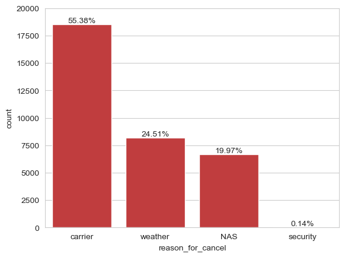

```python
# countplot of reason for cancel
sns.countplot(data=cancel_sub, x='reason_for_cancel', color=sns.color_palette()[3],
              order=cancel_sub['reason_for_cancel'].value_counts().index)
plt.ylim(0, 20000)
insert_pct(cancel_sub, 'reason_for_cancel', 300);
```

This plot shows that the most common reason for flight cancellation is the carrier (airline). The weather follows after this and the National Aviation Services (NAS) follows closely behind. The least common reason for cancellation is security accounting for 0.14% of the cancel cases.

Next, I will look at the distribution of **departure and arrival delays**:

```python
def plot_delay_hist(df, column, ax):
    """function to plot distribution of departure and arrival delays"""
    sns.set_style('white')
    bins = np.arange(df[column].min(), df[column].max()+150, 150)
    ax.hist(df[column], bins = bins)
    plt.yscale('log')
    plt.yticks([10e0, 10e1, 10e2, 10e3, 10e4, 10e5, 10e6, 10e7], [1, 10, 100, 1000, 10000, 100000, 1000000, 10000000]);
```

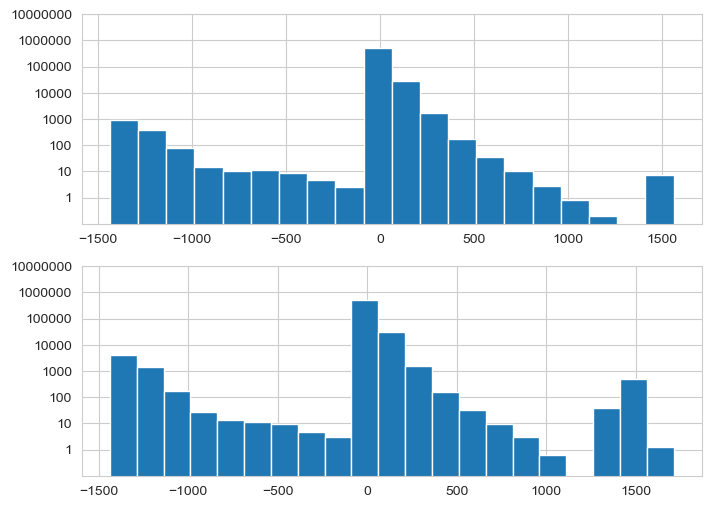

```python
# distribution of
fig, ax = plt.subplots(2, 1, sharey=True, figsize=(8,6))

plot_delay_hist(flights_plot, 'dep_delay', ax[0])
plot_delay_hist(flights_plot, 'arr_delay', ax[1])
```

Initially the plots showed a single peak between -100 and 100 and other parts of the distribution were barely visible because of large number of counts associated with this range. Applying a log transform to the y axis revealed that the plot was multimodal, having three(3) peaks and most points falling below 15 minutes (which constitutes flights considered on time)

The distribution of arrival and departure delays are almost alike. This should be because a departure delay most likely will result in an arrival delay. It also looks like more planes arrive late than take-off late.

Next, I will look at the distribution of travel **'distance'** (in miles):

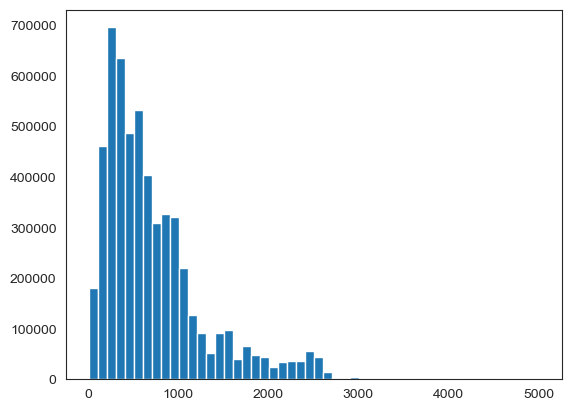

```python
bins = np.arange(flights_plot['distance'].min(), flights_plot['distance'].max()+100, 100)
plt.hist(flights_plot['distance'], bins = bins);
```

The distribution of distance is a right-skewed one. Most flight distances are between 11 - 711 miles, with the most occuring between 211 - 311 miles. The distribution suggests some outliers between about 3000 - 5000 miles. These outliers do not need to be filtered out of the data.

Next, I will look at the counts for time_of_day, day_of_week and months in the dataset:

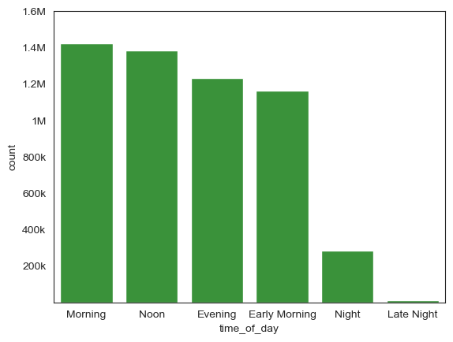

```python
# counts of all flights by time of day
sns.countplot(data=flights_plot, x='time_of_day', color=sns.color_palette()[2],
              order=flights_plot['time_of_day'].value_counts().index)
plt.yticks([2e5, 4e5, 6e5, 8e5, 1e6, 1.2e6, 1.4e6, 1.6e6], ['200k', '400k', '600k', '800k', '1M', '1.2M', '1.4M', '1.6M']);
```

```python
# subset for case where flight was delayed
delay_sub = flights_plot[flights_plot.flight_status == 'delayed']
```

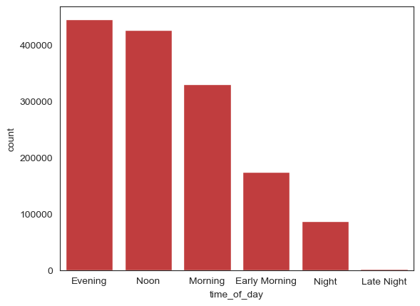

```python
# counts of  delayed flights by time of day
sns.countplot(data=delay_sub, x='time_of_day', color=sns.color_palette()[3],
              order=delay_sub['time_of_day'].value_counts().index);
```

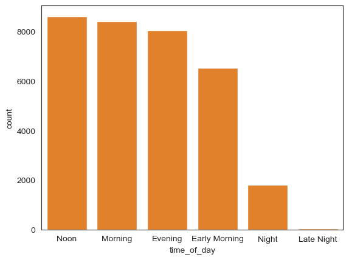

```python
# counts of cancelled flights by time of day
sns.countplot(data=cancel_sub, x='time_of_day', color=sns.color_palette()[1],
              order=cancel_sub['time_of_day'].value_counts().index);
```

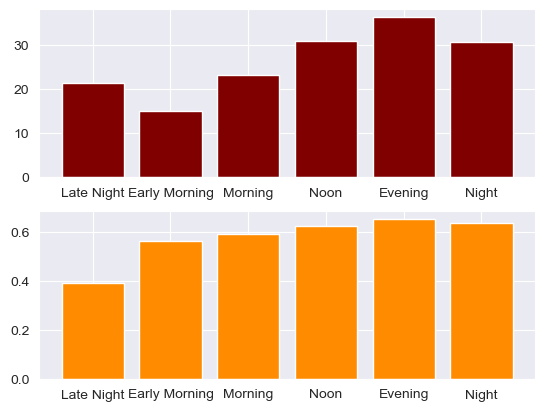

```python
# percentage of flights delayed and cancelled per time of day
times = ['Late Night', 'Early Morning', 'Morning', 'Noon', 'Evening', 'Night']

# get total counts per time_of_day for all flights, for delayed flights and for cancelled flights
total = flights_plot.time_of_day.value_counts()
delay_counts = delay_sub.time_of_day.value_counts()
cancel_counts = cancel_sub.time_of_day.value_counts()


pct_delay = []
pct_cancel = []

# calculate percentages
for time in times:
    delay_pct = 100*delay_counts[time]/total[time]
    cancel_pct = 100*cancel_counts[time]/total[time]

    pct_delay.append(delay_pct)
    pct_cancel.append(cancel_pct)

# plot percentages - delay first
sns.set_style('darkgrid')
fig, ax = plt.subplots(2, 1)
ax[0].bar(x=times, height=pct_delay, color='maroon')
ax[1].bar(x=times, height=pct_cancel, color='darkorange');
```

```python
print('pct_delay:', pct_delay)
print('pct_cancel:', pct_cancel)
```

```
pct_delay: [21.226755081447312, 15.001471977917756, 23.201013733019867, 30.80400786428118, 36.186679155448815, 30.685547992571973]
pct_cancel: [0.38921724088222576, 0.5614973491523038, 0.5912271915338683, 0.6224805434186501, 0.652657910991454, 0.6346821499155746]
```

From the count plot of all flights, we see that most flights are scheduled between Early Morning - Evening (4am - 8pm). Very few are scheduled at Night (between 8pm - midnight) and flights are seldom scheduled after midnight.

From the count for time_of_day in the cancel subset, flights in the noon, morning and evenings, followed by early mornings seem to be the most cancelled while late night and night flights are the least cancelled. However, when compared with the percentage of flights cancelled per time of day, it shows that evening, night and noon flights are the most cancelled.

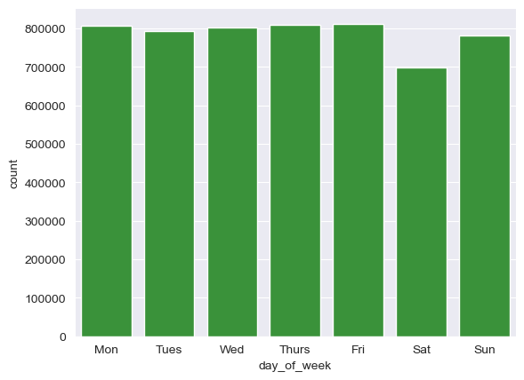

```python
# flights by day of week counts
sns.countplot(data=flights_plot, x='day_of_week', color=sns.color_palette()[2]);
```

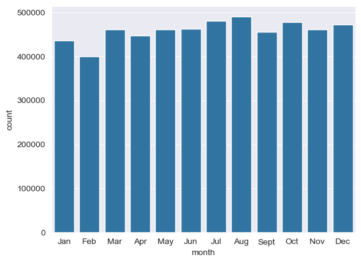

```python
# flights by month of year counts
sns.countplot(data=flights_plot, x='month', color=sns.color_palette()[0]);
```

The number of records for each week day and month are almost evenly distributed. In this case, it would serve our use case well when comparing what week day or month records the most delay and cancellations.

Next is to see the counts for **carriers**(airlines):

```python
flights_plot.replace('US Airways Inc. (Merged with America West 9/05. Reporting for both starting 10/07.)',
                   'US Airways Inc.', inplace=True)
```

```python
delay_sub.replace('US Airways Inc. (Merged with America West 9/05. Reporting for both starting 10/07.)',
                   'US Airways Inc.', inplace=True)
```

```python
cancel_sub.replace('US Airways Inc. (Merged with America West 9/05. Reporting for both starting 10/07.)',
                   'US Airways Inc.', inplace=True)
```

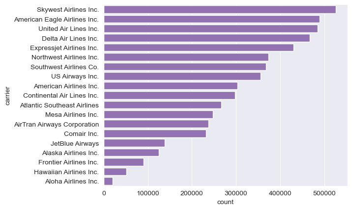

```python
sns.countplot(data=flights_plot, y='carrier', color=sns.color_palette()[4],
              order=flights_plot.carrier.value_counts().index);
```

This plot can be used to pick out the top 5 (or top 10) carriers. Skywest Airlines Inc is leading. American Eagles Airlines Inc and United Air Lines Inc are closely tied, etc.

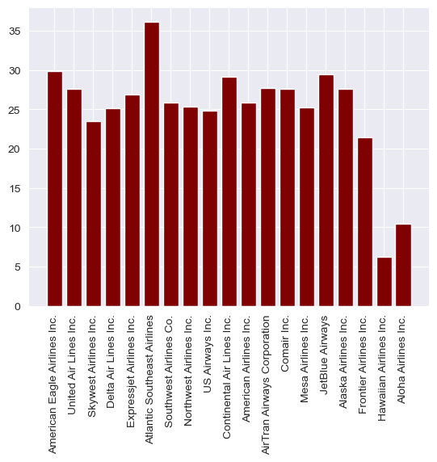

```python
# # percentage of flights delayed and cancelled per carrier

# get total counts per carrier for all flights, for delayed flights and for cancelled flights
total = flights_plot.carrier.value_counts()
delay_counts = delay_sub.carrier.value_counts()
cancel_counts = cancel_sub.carrier.value_counts()


pct_delay = []
pct_cancel = []

# calculate percentages
for carrier in delay_counts.index:
    delay_pct = 100*delay_counts[carrier]/total[carrier]
    pct_delay.append(delay_pct)
for carrier in cancel_counts.index:
    cancel_pct = 100*cancel_counts[carrier]/total[carrier]
    pct_cancel.append(cancel_pct)

# plot percentages - delay first
sns.set_style('darkgrid')

plt.bar(x=delay_counts.index, height=pct_delay, color='maroon')
plt.xticks(rotation=90);
```

Atlantic Southeast Airlines has the most delays (over 36%). It is followed be American Eagle Airlines Inc with about 30% of scheduled flights delayed.

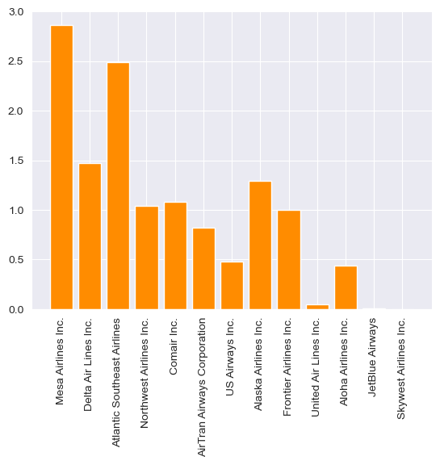

```python
plt.bar(x=cancel_counts.index, height=pct_cancel, color='darkorange')
plt.xticks(rotation=90);
```

Mesa Airlines followed by Atlantic Southeast Airlines has the most cancellations

Finally, for univariate explorations, I will examine the data to see what **cities** are associated with **cancellations** and **delays**.

```python
def plot_sub(data, y, color):
    """function to plot counts of top 10 cities and states in the cancel and delay subsets"""

    fig, ax = plt.subplots(2, 1, sharex=True)

    sns.countplot(data = data, y = y[0], color = color, order=data[y[0]].value_counts().index[:10], ax = ax[0])
    sns.countplot(data = data, y = y[1], color = color, order=data[y[1]].value_counts().index[:10], ax = ax[1])

    plt.show()
```

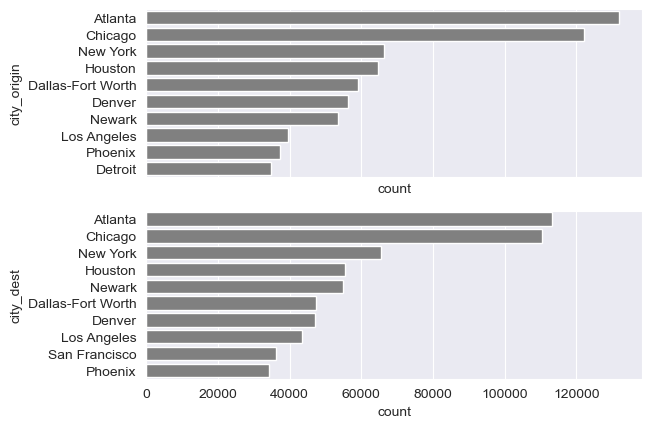

```python
# top 10 cities and states with delayed flights
plot_sub(delay_sub, ['city_origin', 'city_dest'], 'grey')
```

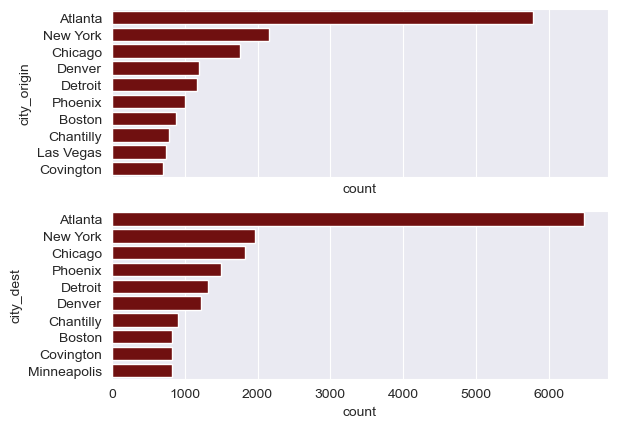

```python
# top 10 cities and states with cancelled flights
plot_sub(cancel_sub, ['city_origin', 'city_dest'], 'maroon')
```

```python
def plot_props(df, column, ylabel):
    """function to plot percentage delay per city"""
    pct_props = []
    col_values = df[column].unique()
    top_10_counts = df[column].value_counts().index[:10]
    for value in col_values:
        pct_prop = 100 * (df[column].value_counts()[value] / flights_plot[column].value_counts()[value])
        pct_props.append(pct_prop)
    prop_dict = {column:col_values, 'pct_delay':pct_props}
    the_df = pd.DataFrame(prop_dict).set_index(column).sort_values(by='pct_delay', ascending=False)
    sns.set_style('whitegrid')
    the_df.loc[top_10_counts].plot(kind='bar', legend=False)
    plt.xlabel(column)
    plt.ylabel(ylabel)
    plt.show()
```

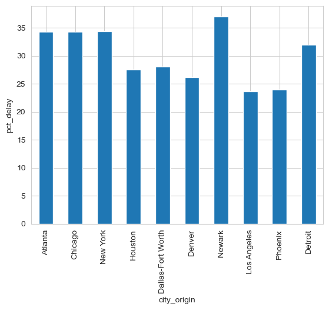

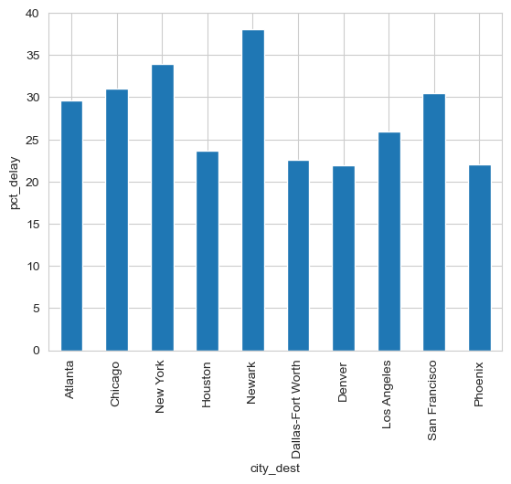

```python
# delay_props
for column in ['city_origin', 'city_dest']:
    plot_props(delay_sub, column, 'pct_delay')
```

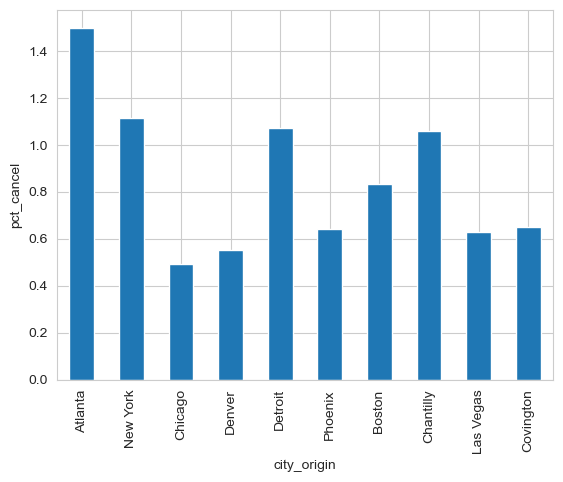

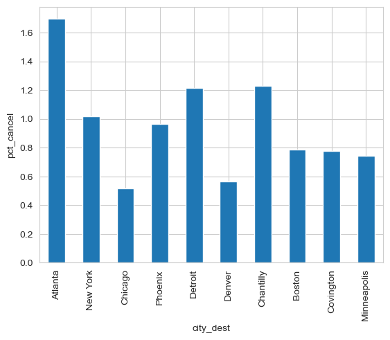

```python
# cancel_props
for column in ['city_origin', 'city_dest']:
    plot_props(cancel_sub, column, 'pct_cancel')
```

The intial countplot for delays showed that Atlanta, Chicago and New York are the top 3 cities with delays. Atlanta and Chicago are closely matched with Chicago having about 50000 more delayed flights than New York. However, when considering the percentages, we see that Newark tops the list while Atlanta, New York, Chicago are tied for origin airports. They are followed by Detroit. In the case of destination airports, the list goes from Newark - New York - Chicago - San Francisco - Atlanta.

The intial countplot for cancelled flights showed that Atlanta, New York, Chicago are the cities with top cancellations. With Atlanta topping the list by about 4000 more cancelled flights that. However, when considering the percentages, we see that Atlanta does top the list followed by New York, Detriot and Chantilly for origin airports. In the case of destination airports, the list goes from Atlanta - Chantilly - Detroit - New York - Phoenix which closely follows New York.

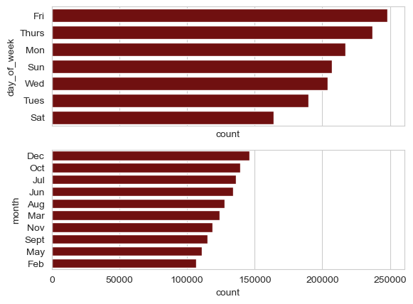

```python
plot_sub(delay_sub, ['day_of_week', 'month'], 'maroon')
```

Most delayed flights are those scheduled on Fridays and Thursdays and the top five months with delay are: Dec, Oct, Jul, Jun & Aug.

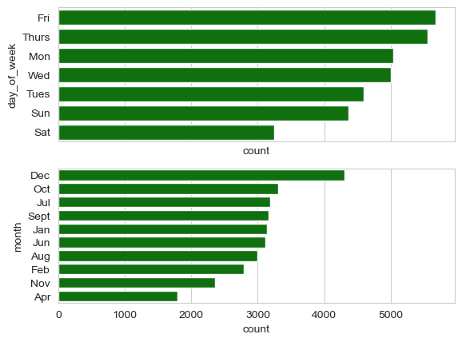

```python
plot_sub(cancel_sub, ['day_of_week', 'month'], 'green')
```

Most delayed flights are those scheduled on Fridays and Thursdays and the top five months with cancelled flights are: Dec, Oct, Jul, Sept & Jan. (Jul, Sept Jan & Jun) are closely tied.

### Discuss the distribution(s) of your variable(s) of interest. Were there any unusual points? Did you need to perform any transformations?

Initially the plots of the departure and arrival delays distribution showed a single peak between -100 and 100 and other parts of the distribution were barely visible because of large number of counts. I applied a log transform to the y axis which revealed that the plot was multimodal, having three(3) peaks.

### Of the features you investigated, were there any unusual distributions? Did you perform any operations on the data to tidy, adjust, or change the form of the data? If so, why did you do this?

The distance distribution had some outliers but they were valid.

## Bivariate Exploration

> In this section, I will be investigating relationships between pairs of variables:

I will begin by exploring the correlation between **arrival delay** and **departure delay** of the delayed flights.

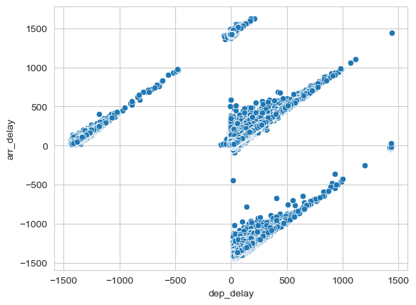

```python
sns.scatterplot(data=delay_sub, x='dep_delay', y='arr_delay');
```

Next we would determine the **average delay per month and day**:

```python
def plot_avg_delay(column):
    """
    function to plot average delay.

    input: column to plot by
    """
    fig, ax = plt.subplots(2, 1, sharex=True, figsize=(6, 6))

    delay_sub.groupby(column)['dep_delay'].mean().plot(ax=ax[0], ylim=(0, 40))
    delay_sub.groupby(column)['arr_delay'].mean().plot(ax=ax[1], ylim=(-5, 30))
    ax[0].set_ylabel('mean departure delay')
    ax[1].set_ylabel('mean arrival delay')

    plt.show()
```

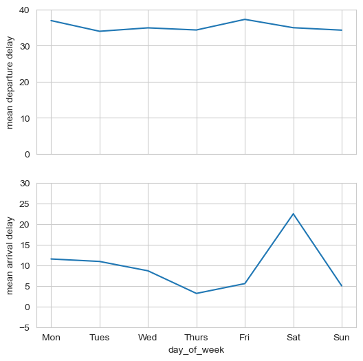

```python
# plot average departure and arrival delays per weekday
plot_avg_delay('day_of_week')
```

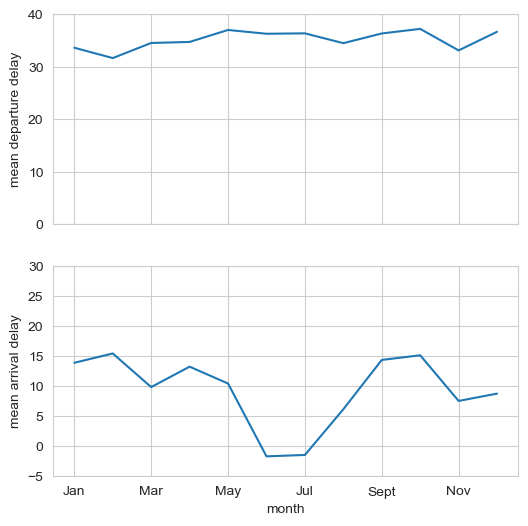

```python
# plot average departure and arrival delays per month
plot_avg_delay('month')
```

Departure delays across all months are between 30 - 40 minutes long. Arrival delays on the other hand follows a downward trend with significant drop in June and July and a spike in September.

I will now consider **reason_for_cancel** per **carrier/airline**:

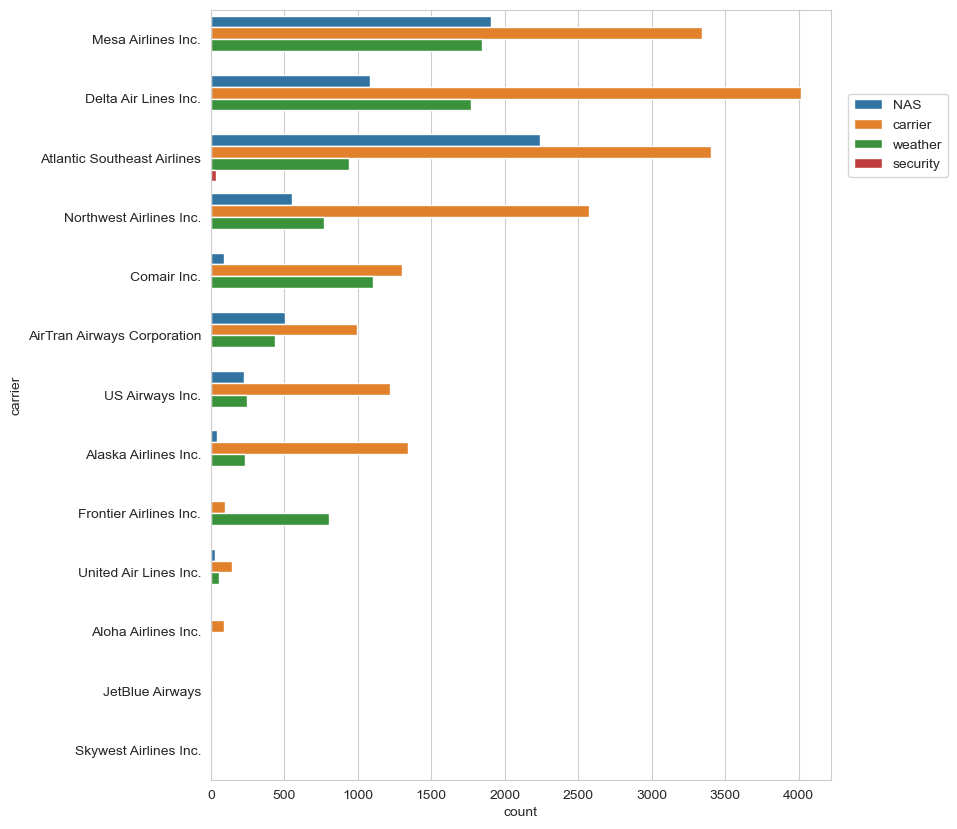

```python
plt.subplots(figsize=(8, 10))
sns.countplot(data=cancel_sub, y='carrier', hue='reason_for_cancel', order=cancel_sub.carrier.value_counts().index)
plt.legend(bbox_to_anchor=(1.2, 0.9));
```

Look at the relationship between **distance** and **dep_delay**

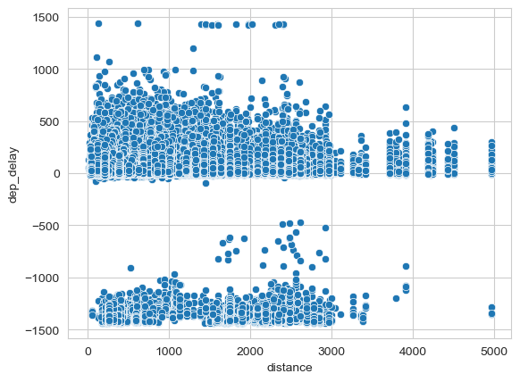

```python
sns.scatterplot(data=delay_sub, x='distance', y='dep_delay');
```

There doesn't seem to be any correlation between departure delay and distance.

Relationship between **time_of_day** and **dep_delay**

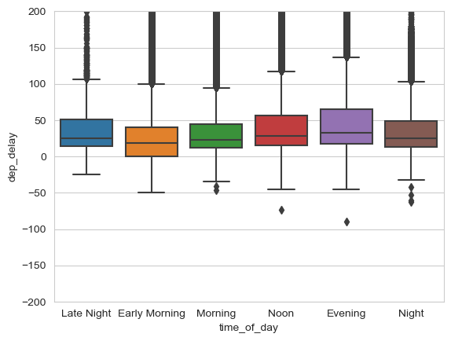

```python
sns.boxplot(data=delay_sub, x='time_of_day', y='dep_delay')
plt.ylim(-200, 200);
```

From the box plot we can see that evenings have the highest departure delay time in minutes. This is followed by Noon and Late Night.

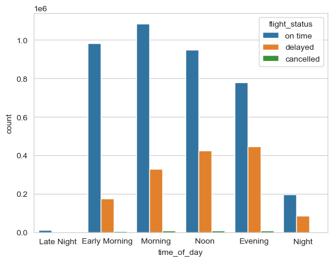

```python
sns.countplot(data=flights_plot, x='time_of_day', hue='flight_status');
```

Evening flights are the most delayed by counts.

### Relationships observed in this part of the investigation.

I observed a strong correlation between arrival delay and departure delay. Arrival delay increases as departure delay increases. This is because a departure delay will most likely result in an arrival delay. Across airlines, carriers are the most reason for flight cancellation. I also observed that evenings generally had the most delayed flights.

## Multivariate Exploration

> Plots of three or more variables to further investigate data.

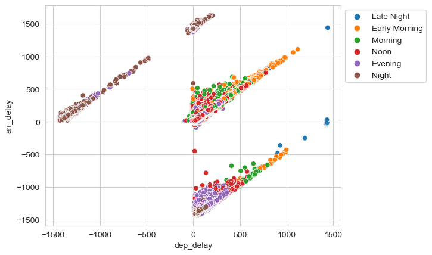

```python
sns.scatterplot(data=delay_sub, x='dep_delay', y='arr_delay', hue='time_of_day')
plt.legend(bbox_to_anchor=(1, 1));
```

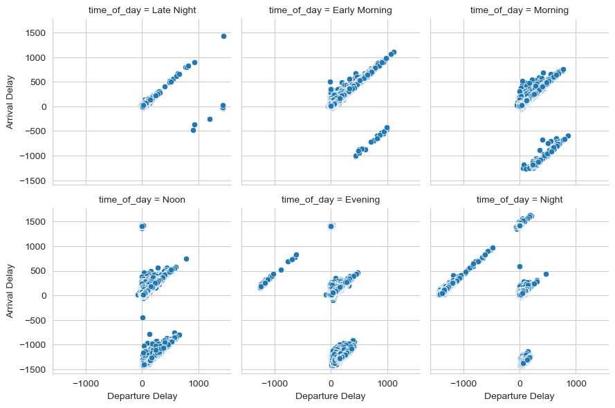

```python
g = sns.FacetGrid(data = delay_sub, col = 'time_of_day', col_wrap = 3)
g.map(sns.scatterplot, 'dep_delay', 'arr_delay')
g.set_xlabels('Departure Delay')
g.set_ylabels('Arrival Delay')

plt.show()
```

For delayed flights, Night and Late Night flights generally have high arrival delays.

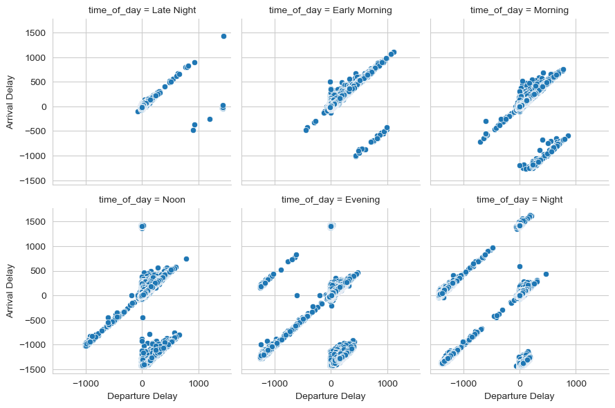

```python
g = sns.FacetGrid(data = flights_plot, col = 'time_of_day', col_wrap = 3)
g.map(sns.scatterplot, 'dep_delay', 'arr_delay')
g.set_xlabels('Departure Delay')
g.set_ylabels('Arrival Delay')

plt.show()
```

Late Night, Early Morning, Morning and Noon flights tend to leave origin airports late. Night and Late Night and Early Morning flights have higher arrival delays

## Conclusions

I set out to answer the following questions in my analysis:

- When is the best time of day/day/week/time of year to fly to minimise delays?
- What is the top reason for flight cancellations?
- Are there certain airlines that are home to more delays or cancellations?

Having performed univariate, bivariate and multivariate exploration of the data, I have the following conclusions:

- Early morning flights are the least delayed and late night flights are the least cancelled.
- The top reason for flight cancellation is the carrier.
- Atlantic Southeast Airlines has the most delays. Mesa Airlines followed by Atlantic Southeast Airlines has the most cancellations. Atlantic Southeast Airlines is associated with lots of delays and cancellations.
- Atlanta is home to more delays.

```python
# save csv files for explanatory visualizations:
flights_plot.to_csv('master_dataset.csv', index=False)
delay_sub.to_csv('delayed_flights.csv', index=False)
cancel_sub.to_csv('cancelled_flights.csv', index=False)
```